# vignette_with_plots

## Produce a bar chart to view the amount of new COVID-19 deaths and infections for a selected date and selected regions of Canada using `day_covid_changes()`

Users can produce a bar chart for a selected date and multiple regions of the amount of new COVID-19 infections and deaths using the `day_covid_changes()` function. This function uses the data frame produced by the `daily_count()` function. The first argument is date for which you would like to see the new COVID-19 data, written in yyyy-mm-dd form. The second and subsequent arguments refer to the regions for which you would like to see the new COVID-19 data bar chart. These can be any of the regions produced by the `Get_data()` function. One region is required, and users can input up to 16 regions.

We can generate a bar chart to view the number of new COVID-19 infections and deaths on April 20th 2020 in Ontario using the following:

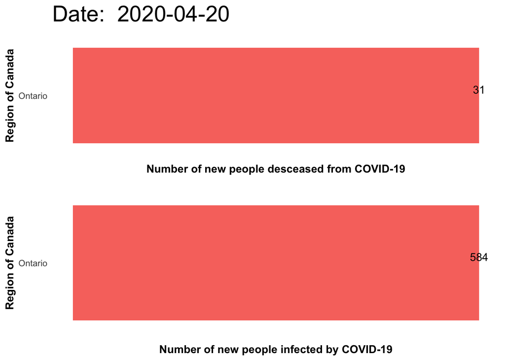

```r
day_covid_changes('2020-04-20', 'Ontario')
```

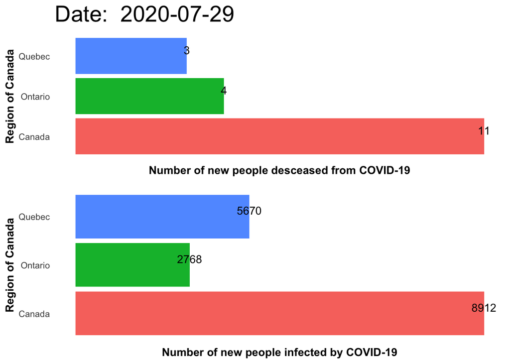

```r
day_covid_changes('2020-07-29', 'Ontario', 'Quebec', 'Canada')
```

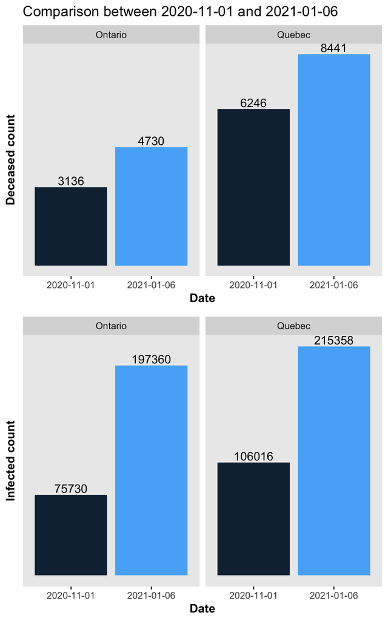

```r
covid_changes_between_days('2020-11-01', '2021-01-06', 'Ontario','Quebec')
```

`covid_changes_between_days('2020-05-18', '2020-05-25', 'Yukon', 'Saskatchewan')`

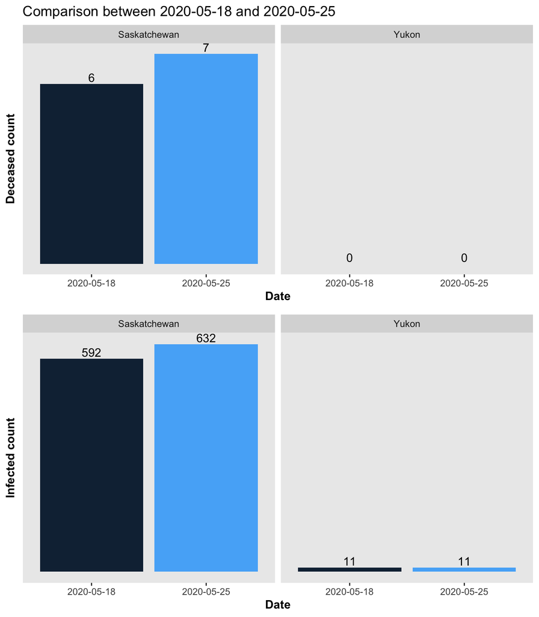

```r
covid_changes_between_days('2020-05-18', '2020-05-25', 'Yukon', 'Saskatchewan')
```